# BIF425 - Functional Genomics: Project 1

Melissa El Feghali

10/13/2020

# 1 Introduction

In this article, we introduce a complete workflow for a (Affymetrix) microarray analysis. Data import, preprocessing, differential expression and enrichment analysis are discussed.

The data set used is from a paper studying the expression profile of human lymphatic endothelial cells under static or oscillatory shear stress conditions in the presence or absence of the Forkhead box protein C2 (FOXC2).

4 samples cultured under static conditions and 4 samples under oscillatory shear stress were tested. Our aim is to analyze whether FOXC2 regulates responses to disturbed flow, thus we studied LECs cultured under static or oscillatory flow conditions, which mimic disturbed flow.

# 2 Workflow package installation

In our Affymetrix micro-array differential expression workflow, we will use a Bioconductor package called “maEndToEnd”.

## 2.1 Workflow package installation from Bioconductor

The above-mentioned package can be installed via the BiocManager.

```r
if (!require("BiocManager"))
    install.packages("BiocManager")
#BiocManager::install("maEndToEnd", version = "devel")
```

## 2.2 Workflow package installation from Github

```r
#install.packages("devtools")
library(devtools)
#devtools::install_github("r-lib/remotes")
library(remotes)
packageVersion("remotes") # has to be 1.1.1.9000 or later
```

```
## [1] '2.2.0.9000'
```

```r
#remotes::install_github("b-klaus/maEndToEnd", ref="master")
```

## 2.3 List of packages required for the workflow

Below, is the list of all the packages that are required by the workflow. We use a call to library() in order to load them.

```r
#General Bioconductor packages
    library(Biobase)
    library(oligoClasses)
#Annotation and data import packages
    library(ArrayExpress)
    library(pd.hugene.1.0.st.v1)
    library(hugene10sttranscriptcluster.db)
#Quality control and pre-processing packages
    library(oligo)
    library(arrayQualityMetrics)

#Analysis and statistics packages
    library(limma)
    library(topGO)
    library(ReactomePA)
    library(clusterProfiler)
```

```r
#Plotting and color options packages
    library(gplots)
    library(ggplot2)
    library(geneplotter)
    library(RColorBrewer)
    library(pheatmap)

#Formatting/documentation packages
   #library(rmarkdown)
   #library(BiocStyle)
    library(dplyr)
    library(tidyr)
#Helpers:
    library(stringr)
    library(matrixStats)
    library(genefilter)
    library(openxlsx)
   #library(devtools)
```

# 3 Downloading the raw data from ArrayExpress

As a first step in our analysis, we need to download the raw data CEL files. The data is available at https://www.ebi.ac.uk/arrayexpress/ with the following accession code : E-GEOD-60152.

We will store these files in the directory raw_data_dir that we will create in a specified location of our choice.

```r
raw_data_dir <- "~/Desktop/BIF/Courses/BIF425_FuntionalGenomics/Project_1/"

if(!dir.exists(raw_data_dir)) {
  dir.create(raw_data_dir)
}
```

We use the getAE function from the ArrayExpress Bioconductor package to obtain the ftp links to the raw data files. We save the date in the raw_data_dir created above. We get a list of the names of the downloaded files.

```r
anno_AE <- getAE("E-GEOD-60152", path = raw_data_dir, type = "raw")
```

```
## Copying raw data files
```

```
## Unpacking data files
```

# 4 Import of annotation data and microarray expression data as “ExpressionSet”

First, we store the SDRF file’s path in sdrf_location. Then, in order to get the sample annotation, we import the SDRF file from the raw data folder using the read.delim function.

```r
sdrf_location <- file.path(raw_data_dir, "E-GEOD-60152.sdrf.txt")
SDRF <- read.delim(sdrf_location)
```

We get the row names of the SDRF file from the column Array.Data.File of the SDRF table data in order to give the row names the sample names (or ID) instead of the sample index.

```r
rownames(SDRF) <- SDRF$Array.Data.File

# Turn the SDRF table into an AnnotatedDataFrame from the Biobase package
SDRF <- AnnotatedDataFrame(SDRF)
```

Now, we create the Expression Set object raw_data and import our CEL files.

```r
raw_data <- oligo::read.celfiles(filenames = SDRF$Array.Data.File, verbose = FALSE, phenoData = SDRF)
```

```
## Reading in : GSM1466666_osc_siFoxC2_C10.CEL
## Reading in : GSM1466665_osc_siFoxC2_B4.CEL
## Reading in : GSM1466664_osc_siAS_C9.CEL
## Reading in : GSM1466663_osc_siAS_B3.CEL
## Reading in : GSM1466662_stat_siFoxC2_C8.CEL
## Reading in : GSM1466661_stat_siFoxC2_B2.CEL
## Reading in : GSM1466660_stat_siAS_C7.CEL
## Reading in : GSM1466659_stat_siAS_B1.CEL
```

```r
# Check if all the data set was read correctly or not
stopifnot(validObject(raw_data))
```

We use the pData function to access the phenoData in our ExpressionSet.

```r
# We can directly view the whole table without using the head() function since we only have a total of 8 rows
(Biobase::pData(raw_data))
```

```
##                                 Source.Name
## GSM1466666_osc_siFoxC2_C10.CEL GSM1466666 1
## GSM1466665_osc_siFoxC2_B4.CEL  GSM1466665 1
## GSM1466664_osc_siAS_C9.CEL     GSM1466664 1
## GSM1466663_osc_siAS_B3.CEL     GSM1466663 1
## GSM1466662_stat_siFoxC2_C8.CEL GSM1466662 1
## GSM1466661_stat_siFoxC2_B2.CEL GSM1466661 1
## GSM1466660_stat_siAS_C7.CEL    GSM1466660 1
## GSM1466659_stat_siAS_B1.CEL    GSM1466659 1
##                                                                                           Comment..Sample_description.
## GSM1466666_osc_siFoxC2_C10.CEL Gene expression data from FOXC2-KD human intestinal LEC grown in oscillatory conditions
## GSM1466665_osc_siFoxC2_B4.CEL  Gene expression data from FOXC2-KD human intestinal LEC grown in oscillatory conditions
## GSM1466664_osc_siAS_C9.CEL      Gene expression data from control human intestinal LEC grown in oscillatory conditions
## GSM1466663_osc_siAS_B3.CEL      Gene expression data from control human intestinal LEC grown in oscillatory conditions
## GSM1466662_stat_siFoxC2_C8.CEL      Gene expression data from FOXC2-KD human intestinal LEC grown in static conditions
## GSM1466661_stat_siFoxC2_B2.CEL      Gene expression data from FOXC2-KD human intestinal LEC grown in static conditions
## GSM1466660_stat_siAS_C7.CEL          Gene expression data from control human intestinal LEC grown in static conditions
## GSM1466659_stat_siAS_B1.CEL          Gene expression data from control human intestinal LEC grown in static conditions
##                                                                      Comment..Sample_source_name.
## GSM1466666_osc_siFoxC2_C10.CEL Human intestinal lymphatic endothelial cells isolated from jejunum
## GSM1466665_osc_siFoxC2_B4.CEL  Human intestinal lymphatic endothelial cells isolated from jejunum
## GSM1466664_osc_siAS_C9.CEL     Human intestinal lymphatic endothelial cells isolated from jejunum
## GSM1466663_osc_siAS_B3.CEL     Human intestinal lymphatic endothelial cells isolated from jejunum
## GSM1466662_stat_siFoxC2_C8.CEL Human intestinal lymphatic endothelial cells isolated from jejunum
## GSM1466661_stat_siFoxC2_B2.CEL Human intestinal lymphatic endothelial cells isolated from jejunum
## GSM1466660_stat_siAS_C7.CEL    Human intestinal lymphatic endothelial cells isolated from jejunum
## GSM1466659_stat_siAS_B1.CEL    Human intestinal lymphatic endothelial cells isolated from jejunum
##                                                      Comment..Sample_title.
## GSM1466666_osc_siFoxC2_C10.CEL FOXC2-KD LEC in oscillatory, biological rep2
## GSM1466665_osc_siFoxC2_B4.CEL  FOXC2-KD LEC in oscillatory, biological rep1
## GSM1466664_osc_siAS_C9.CEL      control LEC in oscillatory, biological rep2
## GSM1466663_osc_siAS_B3.CEL      control LEC in oscillatory, biological rep1
## GSM1466662_stat_siFoxC2_C8.CEL      FOXC2-KD LEC in static, biological rep2
## GSM1466661_stat_siFoxC2_B2.CEL      FOXC2-KD LEC in static, biological rep1
## GSM1466660_stat_siAS_C7.CEL          control LEC in static, biological rep2
## GSM1466659_stat_siAS_B1.CEL          control LEC in static, biological rep1
##                                                 Characteristics..cell.type.
## GSM1466666_osc_siFoxC2_C10.CEL Human intestinal lymphatic endothelial cells
## GSM1466665_osc_siFoxC2_B4.CEL  Human intestinal lymphatic endothelial cells
## GSM1466664_osc_siAS_C9.CEL     Human intestinal lymphatic endothelial cells
```

[output cut: 170 more lines]

```
## GSM1466664_osc_siAS_C9.CEL                 EFO_0001461
## GSM1466663_osc_siAS_B3.CEL                 EFO_0001461
## GSM1466662_stat_siFoxC2_C8.CEL
## GSM1466661_stat_siFoxC2_B2.CEL
## GSM1466660_stat_siAS_C7.CEL                EFO_0001461
## GSM1466659_stat_siAS_B1.CEL                EFO_0001461
##                                                             FactorValue..treatment.
## GSM1466666_osc_siFoxC2_C10.CEL 24-hour oscillatory shear stress (1 dyn/cm2; 1/4 Hz)
## GSM1466665_osc_siFoxC2_B4.CEL  24-hour oscillatory shear stress (1 dyn/cm2; 1/4 Hz)
## GSM1466664_osc_siAS_C9.CEL     24-hour oscillatory shear stress (1 dyn/cm2; 1/4 Hz)
## GSM1466663_osc_siAS_B3.CEL     24-hour oscillatory shear stress (1 dyn/cm2; 1/4 Hz)
## GSM1466662_stat_siFoxC2_C8.CEL                                               static
## GSM1466661_stat_siFoxC2_B2.CEL                                               static
## GSM1466660_stat_siAS_C7.CEL                                                  static
## GSM1466659_stat_siAS_B1.CEL                                                  static
```

We have to sub-select the following columns of interest for us :

1. Identifiers of the individuals “Source.Name” and “Assay.Name”
2. Transfection “FactorValue..transfection.”
3. Treatment “FactorValue..treatment.”

```r
Biobase::pData(raw_data) <- Biobase::pData(raw_data) [, c("Source.Name", "Assay.Name", "FactorValue..transfection.", "FactorValue..treatment.")]
```

# 5 Quality control of the raw data

In this step, we check for outliers and try to see whether the data clusters as expected.

By using the function exprs(raw_data), we can access the expression intensity values stored in the assayData sub-object “exprs”.

```r
Biobase::exprs(raw_data)[1:5,]
```

```
##   GSM1466666_osc_siFoxC2_C10.CEL GSM1466665_osc_siFoxC2_B4.CEL
## 1                           4775                          5817
## 2                            155                           210
## 3                           4827                          6316
## 4                            135                           353
## 5                            157                           326
##   GSM1466664_osc_siAS_C9.CEL GSM1466663_osc_siAS_B3.CEL
## 1                       5594                       6561
## 2                        153                        138
## 3                       5835                       7075
## 4                        166                        121
## 5                        111                        148
##   GSM1466662_stat_siFoxC2_C8.CEL GSM1466661_stat_siFoxC2_B2.CEL
## 1                           6508                           4480
## 2                            308                             97
## 3                           6019                           4289
## 4                            238                            110
## 5                            200                            306
##   GSM1466660_stat_siAS_C7.CEL GSM1466659_stat_siAS_B1.CEL
## 1                        5989                        5754
## 2                          95                         156
## 3                        5824                        5925
## 4                          86                         143
## 5                         215                         244
```

We analyze the data on a logarithmic scale using log2 for quality control.

```r
exp_raw <- log2(Biobase::exprs(raw_data))
```

## 5.1 Principle Component Analysis (PCA)

We perform a PCA which requires the expression data to be by column and not by row; this is why we have to transpose. In the PCA, every column which represented a sample will have the probes in and every row that had the probes will have the sample.

```r
PCA_raw <- prcomp(t(exp_raw), scale. = FALSE) # We do not need to scale since we already did the log2 transformation
```

```r
percentVar <- round(100*PCA_raw$sdev^2/sum(PCA_raw$sdev^2),1)

# standard differentiation ratio
sd_ratio <- sqrt(percentVar[2]/percentVar[1])

dataGG <- data.frame(PC1 = PCA_raw$x[,1], PC2 = PCA_raw$x[,2], Transfection = pData(raw_data)$FactorValue..transfection., Treatment = pData(raw_data)$FactorValue..treatment.)
```

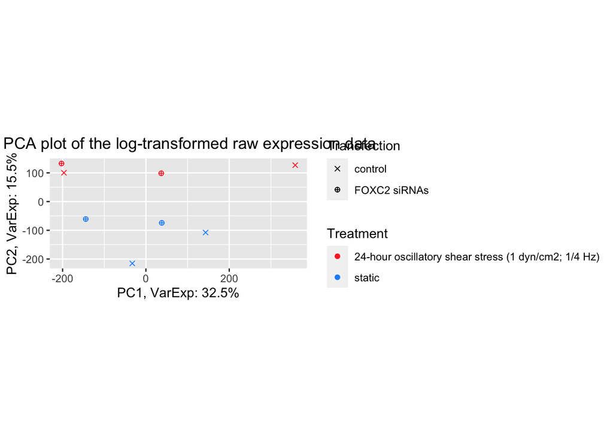

```r
ggplot(dataGG, aes(PC1, PC2)) + geom_point(aes(shape = Transfection, colour = Treatment)) + ggtitle("PCA plot of the log-transformed raw expression data") + xlab(paste0("PC1, VarExp: ", percentVar[1], "%")) + ylab(paste0("PC2, VarExp: ", percentVar[2], "%")) + theme(plot.title = element_text(hjust = 0.4))+ coord_fixed(ratio = sd_ratio) + scale_shape_manual(values = c(4,10)) + scale_color_manual(values = c("firebrick1", "dodgerblue1"))
```

The PCA plot of the raw data shows that the second principal component differentiates between the treatments. This means that the treatment type could be an important driver of gene expression differences.

## 5.2 Boxplot

Additionally, we generate a boxplot to represent the probe intensities with one box per individual microarray.

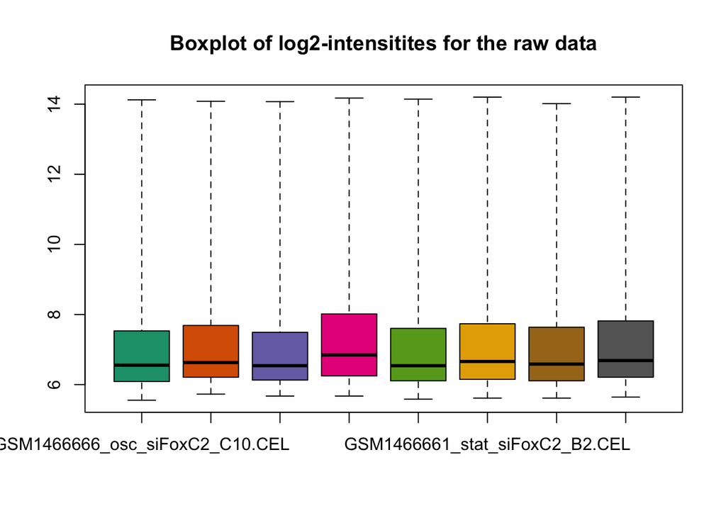

```r
# We can use raw_data here because the oligo::boxplot function can take expression sets as argument and performs a log2-transformation by default.
oligo::boxplot(raw_data, target = "core", main = "Boxplot of log2-intensitites for the raw data")
```

After looking at the boxplot, we notice that the intensity distributions of the individual arrays differ and thus need an appropriate normalization.

## 5.3 Quality Metrics

We generate an html report, containing more elaborate quality control plots along with a description of their aims and an identification of possible outliers.

```r
arrayQualityMetrics(expressionset = raw_data,
    outdir = "~/Desktop/BIF/Courses/BIF425_FuntionalGenomics/Project_1/",
    force = TRUE, do.logtransform = TRUE,
    intgroup = c("FactorValue..transfection.", "FactorValue..treatment."))
```

```
## The report will be written into directory '~/Desktop/BIF/Courses/BIF425_FuntionalGenomics/Project_1/'.
```

# 6 Background adjustment, calibration, summarization and annotation

## 6.1 Backgroung adjustment

This is an essential step in the processing of microarray data due to the fact that a proportion of the measured probe intensities are the result of non-specific hybridization and the noise in the optimal detection system. Thus, observed intensities need to be adjusted to give accurate measurements of specific hybridization.

## 6.2 Calibration

This step, also known as across-array normalization, is needed in order to be able to compare measurements from different array hybridization due to many obscuring sources of variations.

## 6.3 Summarization

After normalization, summarization is necessary to be done because on the Affymetrix platform, transcripts are represented by multiple probes, that is multiple locations on the array. For each gene, the background-adjusted and normalized intensities of all probes need to be summarized into one quantity that estimates an amount proportional to the amount of RNA transcript.

## 6.4 Annotation

After the summarization step, the summarized data can be annotated with various information, e.g. gene symbols and ENSEMBL gene identifiers.

# 7 Relative Log Expression data quality analysis

Relative log expression (RLE) plots are a simple, yet powerful, tool fo visualizing unwanted variation in data. We perform an RMA without prior normalization :

```r
sabine_eset <- oligo::rma(raw_data, target = "core", normalize = FALSE)
```

```
## Background correcting
## Calculating Expression
```

To perform the RLE, we calculate the median log2 intensity of every transcript across all arrays. In order to do this, we calculate the row medians of exprs(sabine_est).

The output data of the RMA function is in log2 scale by default, thus we do not have to apply log2 manually.

```r
row_medians_assayData <- Biobase::rowMedians(as.matrix(Biobase::exprs(sabine_eset)))

# Subtract the transcript median intensity from every transcript intensity using the sweep function
RLE_data <- sweep(Biobase::exprs(sabine_eset), 1, row_medians_assayData)

# Reshape the data into a format that we can use to generate a boxplot for each array
RLE_data <- as.data.frame(RLE_data)
RLE_data_gathered <- tidyr::gather(RLE_data, patient_array, log2_expression_deviation)
```

Let’s keep in mind that the boxplot we are generating is using data that has only been background corrected.

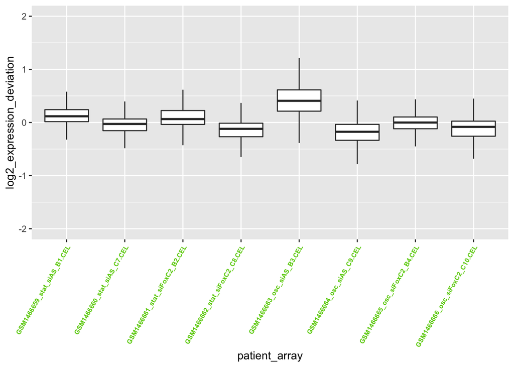

```r
ggplot2::ggplot(RLE_data_gathered, aes(patient_array, log2_expression_deviation)) + geom_boxplot(outlier.shape = NA) + ylim(c(-2, 2)) + theme(axis.text.x = element_text(colour = "chartreuse3", angle = 60, size = 6.5, hjust = 1 , face = "bold"))
```

When the shape and median of a given box varies too much from the bulk, they should be inspected and potentially removed. Arrays that are confirmed to be outliers by heatmap cluster analysis later on, could be removed for subsequent analysis.

# 8 RMA calibration of the data

In this part, we will run a manually generated code that performs the quantile normalization step. Then we will run a built in normalization step and compare the two results.

First, we will generate the background corrected data to pass it on as an argument in the following step.

```r
library(preprocessCore)
bcorrected_data <- rma.background.correct(exprs(raw_data))
```

## 8.1 Manual Function of Quantile Normalization

```r
quantile_normalization <-

  function(bg_corrected_data){
    # bg_corrected data = Background Corrected Data: bcorrected_data

    # For ranking, sorting, accessing and manipulating rows and columns:
    # We focus on using apply() family methods instead of for loops to optimize speed

    # ranked cols matrix: Contains Expressions-> Ranks in their matrix
    ranked_cols_matrix <- apply(bg_corrected_data,2, rank,ties.method="min")

    # we can use apply(data,2,sort) to get the sorted matrix by columns
    sorted_cols_matrix <- apply(bg_corrected_data, 2, sort)

    # Get the mean of every row in the sorted_cols_matrix
    means_by_row <- rowMeans(sorted_cols_matrix)

    # Function replace_w_medians: Replaces all the exprs with the same rank with the medians of their rank
    replace_w_medians <- function(column, medians){
      # Rank-Frequency table: Gets all repeated expressions and their frequency
      rank_freq <- data.frame(table(column))
      rank_freq <- as.matrix(rank_freq)

      # Function to update row medians into row medians but column specific, check below for more...
      update_median <- function(rf, med){
        new_median <- rep(mean(med[as.integer(rf[1]):(as.integer(rf[1])+as.integer(rf[2])-1)]),rf[2])
        return (new_median)
      }
      # All Repeated Ranks will influence the medians => replace the medians with average of medians
      new_medians <- apply(rank_freq,1, update_median, med=means_by_row)
      new_medians <- unlist(new_medians)

      # Index to mean function: Replace all values with rank x with average median of the same rank
      index_to_mean <- function(my_index, my_mean){
        return(my_mean[my_index])
      }
      # Apply index_to_mean on column X
      final_result <- lapply(column, index_to_mean, my_mean=new_medians)
      final_result <- unlist(final_result)
      return(final_result)
    }

    # Apply replace_w_medians to every column of the matrix:
    final_result  <- apply(ranked_cols_matrix,2,replace_w_medians, medians=means_by_row)


    # Return Final Result
    return(final_result)
  }
```

```r
manual_result <- quantile_normalization(bcorrected_data)
head(manual_result)
```

```
##            [,1]      [,2]       [,3]       [,4]      [,5]       [,6]       [,7]
## [1,] 5571.78636 5872.7220 6510.49469 5066.90094 6895.2447 4450.84886 5737.04469
## [2,]  100.67133  141.8834  105.13193   46.88983  262.0596   26.15860   28.90321
## [3,] 5642.64648 6331.2916 6715.61969 5488.96344 6448.5780 4249.85184 5619.65094
## [4,]   76.85334  277.4666  121.15392   34.60779  186.1477   38.58935   19.67281
## [5,]  102.99134  251.9545   52.26056   54.16567  145.1958  228.64173  155.88326
## [6,]   26.97386  206.7553  126.08653   16.76370  292.1942   17.89812   26.83609
##            [,8]
## [1,] 5048.82803
## [2,]   76.51878
## [3,] 5149.74469
## [4,]   64.72803
## [5,]  155.04308
## [6,]   24.79974
```

## 8.2 Built-in Function

```r
builtin_result <- normalize.quantiles(bcorrected_data)
head(builtin_result)
```

```
##            [,1]      [,2]       [,3]       [,4]      [,5]       [,6]       [,7]
## [1,] 5571.86969 5872.4947 6510.49469 5066.86969 6895.2447 4450.86969 5736.86969
## [2,]  100.49469  141.8697  105.24469   46.74470  261.9947   26.15367   29.00673
## [3,] 5642.74469 6331.3072 6715.61969 5488.99469 6448.4947 4249.74469 5619.61969
## [4,]   76.86969  277.6197  121.11969   34.62130  186.1197   38.61995   19.57215
## [5,]  102.99469  251.8697   51.99469   54.11969  145.1197  228.74469  155.99469
## [6,]   27.01889  206.7447  125.99469   16.77844  292.3697   17.93796   26.89389
##            [,8]
## [1,] 5048.86969
## [2,]   76.49469
## [3,] 5149.61969
## [4,]   64.61969
## [5,]  154.99469
## [6,]   24.79203
```

## 8.3 Comparison between the Functions

```r
head(builtin_result - manual_result)
```

```
##             [,1]        [,2]        [,3]        [,4]        [,5]        [,6]
## [1,]  0.08333333 -0.22727273  0.00000000 -0.03125000  0.00000000  0.02083333
## [2,] -0.17664042 -0.01373106  0.11276135 -0.14512875 -0.06491853 -0.00493122
## [3,]  0.09821429  0.01562500  0.00000000  0.03125000 -0.08333333 -0.10714286
## [4,]  0.01635080  0.15312500 -0.03422435  0.01351034 -0.02805233  0.03060305
## [5,]  0.00335443 -0.08484043 -0.26586681 -0.04597519 -0.07608225  0.10296763
## [6,]  0.04502511 -0.01061525 -0.09183512  0.01474133  0.17544987  0.03984494
##             [,7]         [,8]
## [1,] -0.17500000  0.041666667
## [2,]  0.10352093 -0.024089806
## [3,] -0.03125000 -0.125000000
## [4,] -0.10065204 -0.108340106
## [5,]  0.11143808 -0.048382520
## [6,]  0.05779653 -0.007710431
```

By comparing the two Quantile Normalization functions, we notice that little or no difference is presence between the results.

## 8.4 Full RMA algorithm

We will now perform the full RMA algorithm that includes background correction, normalization and summarization.

```r
sabine_eset_norm <- oligo::rma(raw_data, target = "core")
```

```
## Background correcting
## Normalizing
## Calculating Expression
```

# 9 Quality Assessment of the calibrated data

## 9.1 PCA Analysis

We perform a PCA analysis of the calibrated data, analogously to the one with the raw data.

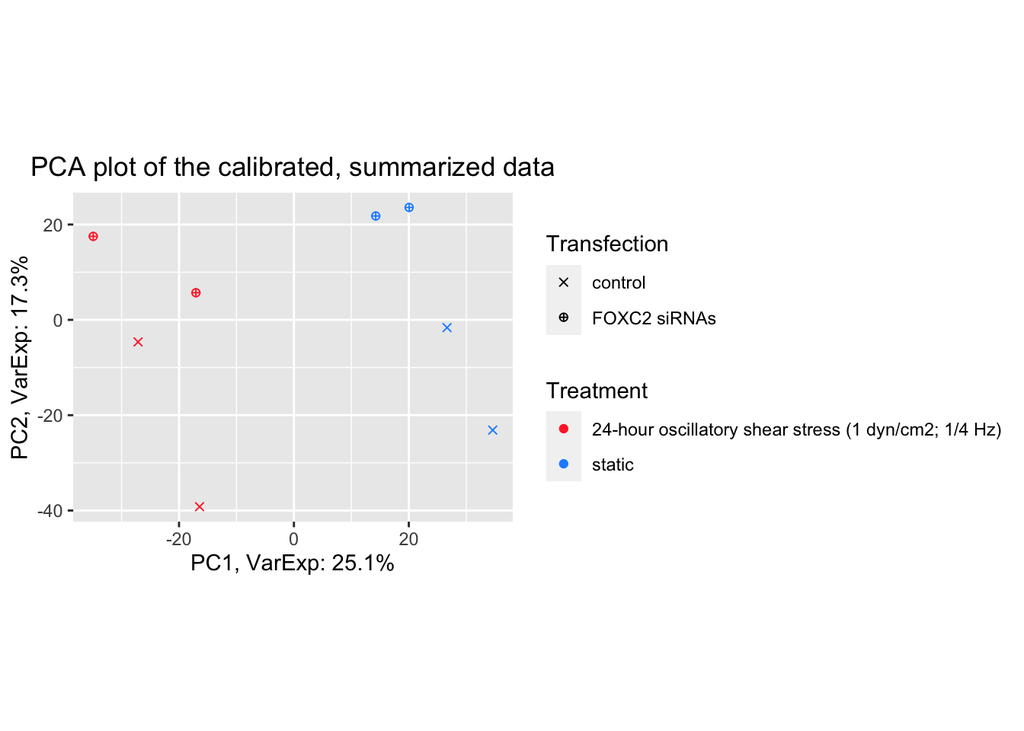

```r
exp_sabine <- Biobase::exprs(sabine_eset_norm)
PCA <- prcomp(t(exp_sabine), scale = FALSE)

percentVar <- round(100*PCA$sdev^2/sum(PCA$sdev^2),1)
sd_ratio <- sqrt(percentVar[2] / percentVar[1])

dataGG <- data.frame(PC1 = PCA$x[,1], PC2 = PCA$x[,2], Transfection = Biobase::pData(sabine_eset_norm)$FactorValue..transfection., Treatment = Biobase::pData(sabine_eset_norm)$FactorValue..treatment.)

ggplot(dataGG, aes(PC1, PC2)) + geom_point(aes(shape = Transfection, colour = Treatment)) + ggtitle("PCA plot of the calibrated, summarized data") + xlab(paste0("PC1, VarExp: ", percentVar[1], "%")) + ylab(paste0("PC2, VarExp: ", percentVar[2], "%")) + theme(plot.title = element_text(hjust = 0.5)) + coord_fixed(ratio = sd_ratio) + scale_shape_manual(values = c(4,10)) + scale_color_manual(values = c("firebrick1", "dodgerblue1"))
```

In comparison to the first PCA analysis before RMA, we notice that the first principle component differentiates now between the treatments. This indicates that now differential expression between the treatments is the dominant source of variation. Note that the second principal component separates between the transfections.

## 9.2 Heatmap Clustering Analysis

We will plot a heatmap with the sample-to-sample distances with the sample names as row-names. We want to see how well the samples cluster for transfection (control or FOXC2) and treatment (OSS or static), respectively.

```r
transfection_names <- ifelse(str_detect(pData(sabine_eset_norm)$FactorValue..transfection.,"FOXC2 siRNAs"), "FOXC2", "control")

treatment_names <- ifelse(str_detect(pData(sabine_eset_norm)$FactorValue..treatment.,"static"), "static", "OSS")

annotation_for_heatmap <- data.frame(Transfection = transfection_names,  Treatment = treatment_names)

row.names(annotation_for_heatmap) <- row.names(pData(sabine_eset_norm))
```

```r
# Compute the sample-to-sample distances
dists <- as.matrix(dist(t(exp_sabine), method = "manhattan")) # we transpose the expression values

rownames(dists) <- row.names(pData(sabine_eset_norm))
hmcol <- rev(colorRampPalette(RColorBrewer::brewer.pal(10, "PuBu"))(255))
```

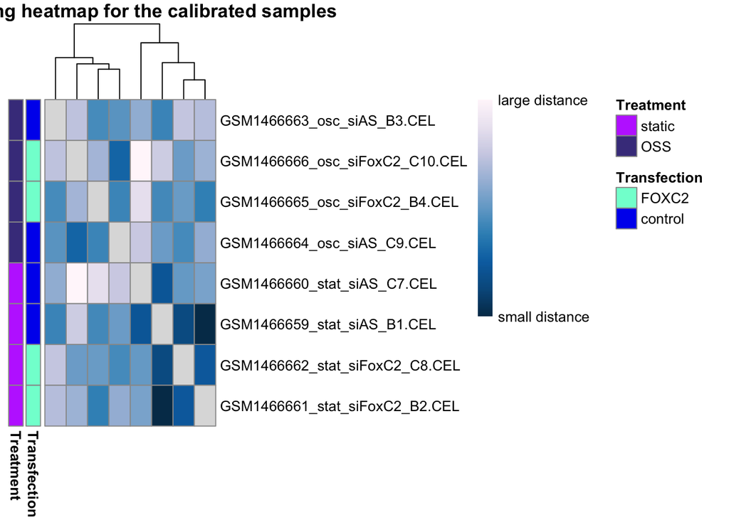

```r
colnames(dists) <- NULL
diag(dists) <- NA

ann_colors <- list(Transfection = c(FOXC2 = "aquamarine1", control = "blue2"), Treatment = c(static = "darkorchid1", OSS = "darkslateblue")
                   )
pheatmap(dists, col = (hmcol), annotation_row = annotation_for_heatmap, annotation_colors = ann_colors, legend = TRUE, treeheight_row = 0, legend_breaks = c(min(dists, na.rm = TRUE), max(dists, na.rm = TRUE)), legend_labels = (c("small distance", "large distance")), main = "Clustering heatmap for the calibrated samples")
```

On the heatmap, we see that the samples cluster more strongly by treatment, confirming the impression from the PCA plot.

# 10 Filtering based on intensity

We now filter out lowly expressed genes. We will perform a “soft” intensity based filtering here, since this is recommended by the limma, used in the experiment.

For intensity-based filtering, we calculate the row-wise medians from the expression data, as they represent the transcript medians, and assign them to sabine_medians. From this we create a histogram:

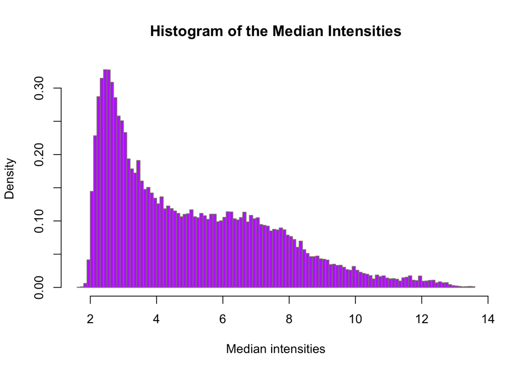

```r
sabine_medians <- rowMedians(Biobase::exprs(sabine_eset_norm))

hist_res <- hist(sabine_medians, 100, col = "darkorchid1", freq = FALSE, main = "Histogram of the Median Intensities", border = "antiquewhite4", xlab = "Median intensities")
```

We plot the same histogram as before and add the threshold line with the abline() function.

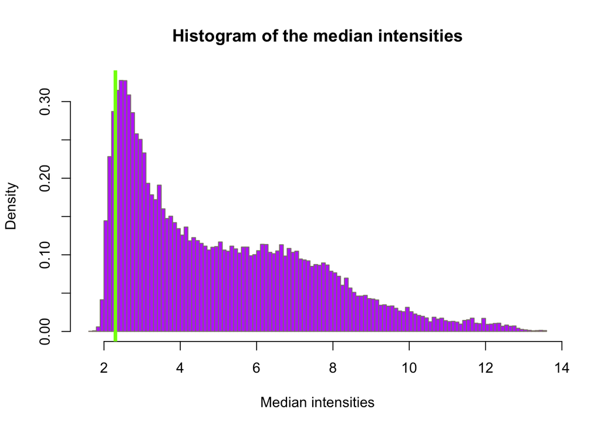

```r
man_threshold <- 2.3

hist_res <- hist(sabine_medians, 100, col = "darkorchid1", freq = FALSE, main = "Histogram of the median intensities", border = "antiquewhite4", xlab = "Median intensities")

abline(v = man_threshold, col = "chartreuse", lwd = 4)
```

Transcripts that do not have intensities larger than the threshold in at least as many arrays as the smallest experimental group are excluded.

In order to do so, we first have to get a list with the number of samples in the experimental groups:

```r
no_of_samples <- table(paste0(pData(sabine_eset_norm)$FactorValue..transfection., "_", pData(sabine_eset_norm)$FactorValue..treatment.))
no_of_samples
```

```
##
##      control_24-hour oscillatory shear stress (1 dyn/cm2; 1/4 Hz)
##                                                                 2
##                                                    control_static
##                                                                 2
## FOXC2 siRNAs_24-hour oscillatory shear stress (1 dyn/cm2; 1/4 Hz)
##                                                                 2
##                                               FOXC2 siRNAs_static
##                                                                 2
```

```r
samples_cutoff <- min(no_of_samples)

# Evaluates whether the number of arrays where the median intensity passes the threshold is greater than the samples_cutoff and returns TRUE or FALSE for each row
idx_man_threshold <- apply(Biobase::exprs(sabine_eset_norm), 1, function(x){ sum(x > man_threshold) >= samples_cutoff})

# Table that summarizes the results and gives an overview over how many genes are filtered out
table(idx_man_threshold)
```

```
## idx_man_threshold
## FALSE  TRUE
##  1126 32171
```

We subset our expression set to sabine_manfiltered and keep the TRUE elements of idx_man_threshold

```r
sabine_manfiltered <- subset(sabine_eset_norm, idx_man_threshold)
```

# 11 Annotation of the transcript clusters

We add “feature data” - annotation information to the transcript cluster identifiers stored in the featureData of our ExpressionSet.

```r
# We used the function select to query the gene symbols and associated short descriptions for the transcript clusters
anno_sabine <- AnnotationDbi::select(hugene10sttranscriptcluster.db, keys = (featureNames(sabine_manfiltered)), columns = c("SYMBOL", "GENENAME"), keytype = "PROBEID")
anno_sabine <- subset(anno_sabine, !is.na(SYMBOL))
```

Now, we need to filter out the probes that do not map to a gene, in other words, that do not have a gene symbol assigned.

We compute a summary table to see how many transcript-cluster identifiers map to multiple gene symbols.

```r
# Group anno_sabine by their PROBEID
anno_grouped <- group_by(anno_sabine, PROBEID)

# Summarize the groups and indicate the number of different genes assigned to a transcript cluster
anno_summarized <- dplyr::summarize(anno_grouped, no_of_matches = n_distinct(SYMBOL))
head(anno_summarized)
```

```
## # A tibble: 6 x 2
##   PROBEID no_of_matches
##   <chr>           <int>
## 1 7896740             3
## 2 7896742             3
## 3 7896744             4
## 4 7896754             1
## 5 7896756             2
## 6 7896759             1
```

In the step below, we filter the PROBEIDs with multiple matches:

```r
anno_filtered <- filter(anno_summarized, no_of_matches > 1)
head(anno_filtered)
```

```
## # A tibble: 6 x 2
##   PROBEID no_of_matches
##   <chr>           <int>
## 1 7896740             3
## 2 7896742             3
## 3 7896744             4
## 4 7896756             2
## 5 7896937             3
## 6 7896961             3
```

```r
probe_stats <- anno_filtered

nrow(probe_stats)
```

```
## [1] 2163
```

We have close to 2200 transcript clusters that map to multiple gene symbols. Seeing that it is difficult to decide which mapping is “correct”, we exclude these transcript clusters.

```r
# Assign probe IDs with multiple mappings to the variable ids_to_exclude
ids_to_exlude <- (featureNames(sabine_manfiltered) %in% probe_stats$PROBEID)

table(ids_to_exlude)
```

```
## ids_to_exlude
## FALSE  TRUE
## 30008  2163
```

```r
# Generate an expression set without ids_to_exclude
sabine_final <- subset(sabine_manfiltered, !ids_to_exlude)
validObject(sabine_final)
```

```
## [1] TRUE
```

Now that we have just excluded probe IDs from the assay data, we also have to also exclude them from the feature data anno_sabine.

```r
head(anno_sabine)
```

```
##      PROBEID      SYMBOL
## 4047 7896740       OR4F4
## 4048 7896740      OR4F17
## 4049 7896740       OR4F5
## 4050 7896742 LINC00266-1
## 4051 7896742      PCMTD2
## 4052 7896742   LINC01881
##                                                                          GENENAME
## 4047                             olfactory receptor family 4 subfamily F member 4
## 4048                            olfactory receptor family 4 subfamily F member 17
## 4049                             olfactory receptor family 4 subfamily F member 5
## 4050                                 long intergenic non-protein coding RNA 266-1
## 4051 protein-L-isoaspartate (D-aspartate) O-methyltransferase domain containing 2
## 4052                                  long intergenic non-protein coding RNA 1881
```

```r
# Generate a column PROBEID in fData(sabine_final) and assign the row names of fData(sabine_final) to it
fData(sabine_final)$PROBEID <- rownames(fData(sabine_final))
```

```r
# left-join keeps the rows and columns of the first argument and adds the corresponding column entries of the second argument
fData(sabine_final) <- left_join(fData(sabine_final), anno_sabine)
# Restore rownames after left_join
rownames(fData(sabine_final)) <- fData(sabine_final)$PROBEID
validObject(sabine_final)
```

```
## [1] TRUE
```

# 12 Linear Models

For the subsequent linear modeling of the data, we introduce the abbreviations “Stat” and “OSS” for the treatment types, and “Ctrl” and “FOXC2” for the transfections, respectively:

```r
treatment <- str_replace_all(Biobase::pData(sabine_final)$FactorValue..treatment.,
                  " ", "_")

treatment <- ifelse(treatment == "static",
                 "Stat", "OSS")

transfection <-
  str_replace_all(Biobase::pData(sabine_final)$FactorValue..transfection.,
                  " ", "_")
transfection <-
  ifelse(str_detect(Biobase::pData(sabine_final)$FactorValue..transfection.,
                    "control"), "Ctrl", "FOXC2")
```

```r
design_sabine = model.matrix(~ 0 + pData(sabine_final)$FactorValue..treatment)
colnames(design_sabine)[1:2] <- c("Stat", "OSS")
rownames(design_sabine) <- Biobase::pData(sabine_final)$Source.Name

contrast_matrix <- makeContrasts(Stat-OSS, levels = design_sabine)
sabine_fit <- eBayes(contrasts.fit(lmFit(sabine_final,
                                design = design_sabine),
                                contrast_matrix))
```

## 12.1 Extracting results

Finally, we extract the number of deferentially expressed genes. We extract the results for both static and oscillatory shear stress, and the results are sorted by their absolute t-statistics.

```r
table_OSS <- topTable(sabine_fit, number = Inf)
head(table_OSS)
```

```
##         PROBEID  SYMBOL                                   GENENAME     logFC
## 8068713 8068713     MX1                   MX dynamin like GTPase 1 -3.364904
## 8083569 8083569  TIPARP TCDD inducible poly(ADP-ribose) polymerase  3.281278
## 7989985 7989985  ITGA11                  integrin subunit alpha 11  3.664580
## 8002303 8002303    NQO1            NAD(P)H quinone dehydrogenase 1  2.856684
## 7971296 7971296  EPSTI1           epithelial stromal interaction 1 -2.322869
## 8102800 8102800 SLC7A11          solute carrier family 7 member 11  3.797314
##          AveExpr         t      P.Value    adj.P.Val         B
## 8068713 7.047062 -40.41207 1.594463e-11 4.784665e-07 11.676914
## 8083569 8.358282  27.01262 5.911442e-10 8.869528e-06 10.567410
## 7989985 6.785106  23.02795 2.454468e-09 2.455123e-05  9.939442
## 8002303 9.493302  20.18534 7.909062e-09 5.933378e-05  9.332656
## 7971296 4.733905 -19.52444 1.062019e-08 6.373814e-05  9.166672
## 8102800 7.937246  18.36483 1.824304e-08 9.123953e-05  8.848260
```

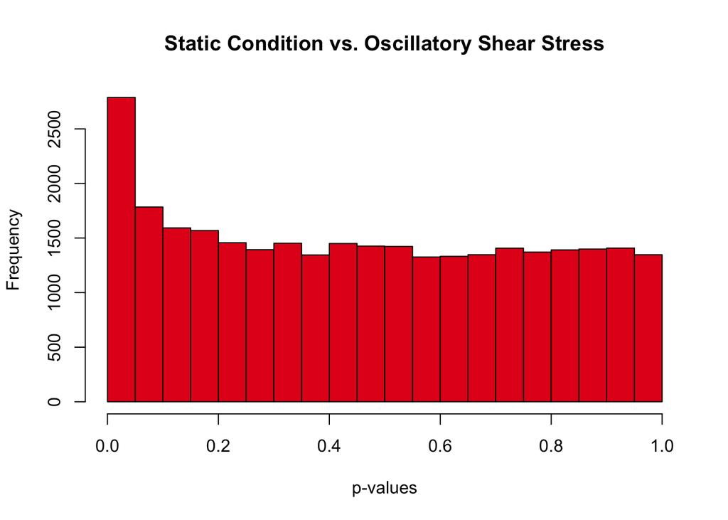

```r
hist(table_OSS$P.Value, col = brewer.pal(3, name = "Set1")[1], main = "Static Condition vs. Oscillatory Shear Stress", xlab="p-values")
```

```r
nrow(subset(table_OSS, P.Value < 0.05))
```

```
## [1] 2788
```

```r
tail(subset(table_OSS, P.Value< 0.001))
```

```
##         PROBEID  SYMBOL                                               GENENAME
## 8138231 8138231  THSD7A             thrombospondin type 1 domain containing 7A
## 7958200 7958200    EID3       EP300 interacting inhibitor of differentiation 3
## 8035566 8035566  HOMER3                               homer scaffold protein 3
## 8092849 8092849 ATP13A3                                            ATPase 13A3
## 8035980 8035980   RHPN2                 rhophilin Rho GTPase binding protein 2
## 8163908 8163908  GGTA1P glycoprotein alpha-galactosyltransferase 1, pseudogene
##              logFC  AveExpr         t      P.Value  adj.P.Val          B
## 8138231 -1.3122626 6.851543 -4.785198 0.0009822780 0.08251380 -0.4485204
## 7958200  1.2669457 5.671233  4.784692 0.0009829744 0.08251380 -0.4492273
## 8035566 -0.7561572 7.591514 -4.783656 0.0009844021 0.08251380 -0.4506753
## 8092849  0.6235878 7.556253  4.781375 0.0009875526 0.08254729 -0.4538631
## 8035980 -0.8603091 6.022265 -4.776534 0.0009942743 0.08287829 -0.4606306
## 8163908 -1.8702665 5.413063 -4.773433 0.0009986056 0.08296243 -0.4649673
```

```r
total_genenumber_OSS <- length(subset(table_OSS, P.Value < 0.05)$SYMBOL)
```

## 12.3 Visualization of DE analysis results - volcano plot

For a visualization of the deferentially expressed genes, we create a volcano plot, which is commonly used to summarize the results of a differential expression analysis in a single figure.

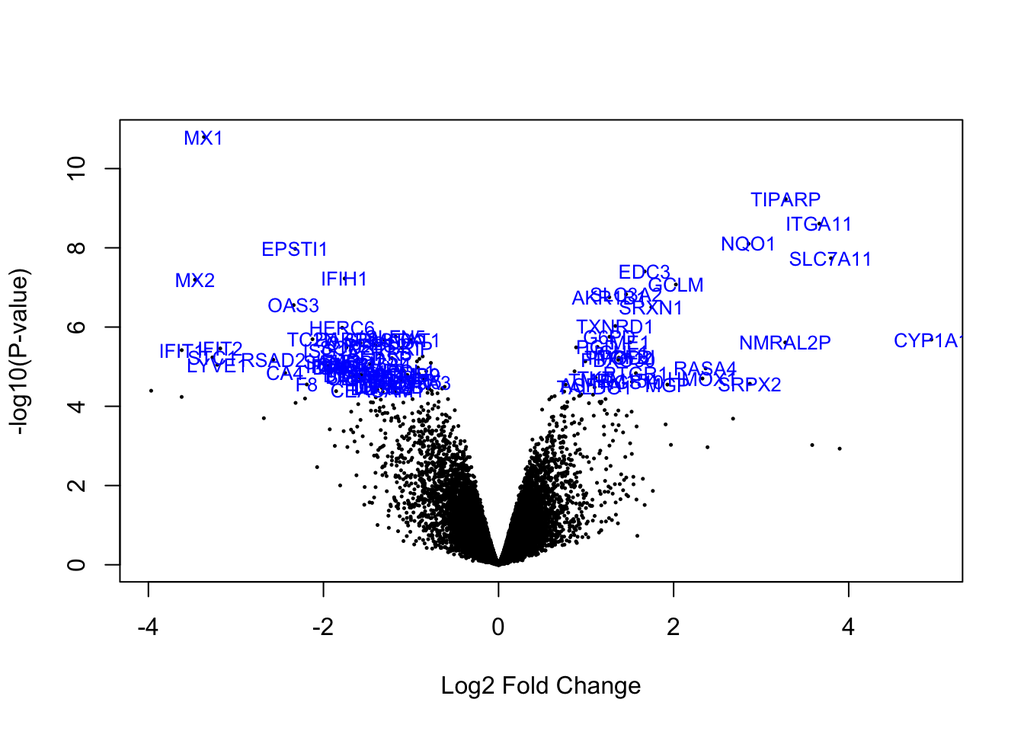

```r
volcano_names = ifelse(abs(sabine_fit$coefficients)>=1, sabine_fit$genes$SYMBOL, NA)

volcanoplot(sabine_fit, coef = 1L, style = "p-value", highlight = 100, names = volcano_names, xlab = "Log2 Fold Change", ylab = NULL, pch = 16, cex = 0.35)
```

# 13 Gene Ontology (GO) based Enrichment Analysis

```r
#DE_genes_OSS <- subset(table_OSS, adj.P.Val < 0.1)$PROBEID
```

## 13.1 Matching the background set of genes

For every deferentially expressed gene, we try to find genes with similar expression with genefinder. The genefinder function returns a list with two elements for each gene: one with the indices of the background genes found and one with the distances to the DE-genes.

```r
#back_genes_idx <- genefilter::genefinder(sabine_final, as.character(DE_genes_OSS), method = "manhattan", scale = "none")
```

We extract the PROBEIDs, which correspond to the indices.

```r
#back_genes_idx <- sapply(back_genes_idx, function(x)x$indices)
```

We then create a vector back_genes containing all background gene PROBEID.

```r
#back_genes <- featureNames(palmieri_final)[back_genes_idx]
#back_genes <- setdiff(back_genes, DE_genes_OSS)


#intersect(back_genes, DE_genes_OSS)
```

```r
#length(back_genes)
```

```r
#multidensity(list( all = table_OSS[,"AveExpr"] ,fore = table_OSS[DE_genes_OSS , "AveExpr"], back = table_OSS[rownames(table_OSS) %in% back_genes, "AveExpr"]), col = c("#e46981", "#ae7ee2", "#a7ad4a"), xlab = "mean expression", main = "DE genes for OSS-background-matching")
```

## 13.2 Running topGO

First, we create a named vector all_genes with all genes to be analyzed: DE-genes and background gene.

```r
#gene_IDs <- rownames(table_OSS)
#in_universe <- gene_IDs %in% c(DE_genes_OSS, back_genes)
#in_selection <- gene_IDs %in% DE_genes_OSS

#all_genes <- in_selection[in_universe]
#all_genes <- factor(as.integer(in_selection[in_universe]))
#names(all_genes) <- gene_IDs[in_universe]
```

We now initialize the topGO data set, using the GO annotations contained in the annotation data base for the chip we are using.

```r
#top_GO_data <- new("topGOdata", ontology = "BP", allGenes = all_genes, nodeSize = 10, annot = annFUN.db, affyLib = "hugene10sttranscriptcluster.db")
```

```r
#result_top_GO_elim <- runTest(top_GO_data, algorithm = "elim", statistic = "Fisher")
#result_top_GO_classic <- runTest(top_GO_data, algorithm = "classic", statistic = "Fisher")
```

```r
#res_top_GO <- GenTable(top_GO_data, Fisher.elim = result_top_GO_elim, Fisher.classic = result_top_GO_classic, orderBy = "Fisher.elim" , topNodes = 100)

#genes_top_GO <- printGenes(top_GO_data, whichTerms = res_top_GO$GO.ID, chip = "hugene10sttranscriptcluster.db", geneCutOff = 1000)

#res_top_GO$sig_genes <- sapply(genes_top_GO, function(x){ str_c(paste0(x[x$'raw p-value' == 2, "Symbol.id"],";"), collapse = "")})

#head(res_top_GO[,1:8], 20)
```

# 14 A pathway enrichment analysis using reactome

The package ReactomePA requires entrez identifiers, so we convert our PROBEIDs to entrez identifiers using the function mapIDs.

```r
entrez_ids <- mapIds(hugene10sttranscriptcluster.db, keys = rownames(table_OSS), keytype = "PROBEID", column = "ENTREZID")
#reactome_enrich <- enrichPathway(gene = entrez_ids[DE_genes_OSS], universe = entrez_ids[c(DE_genes_OSS, back_genes)], organism = "human", pvalueCutoff = 0.05, qvalueCutoff = 0.9, readable = TRUE)

#reactome_enrich@result$Description <- paste0(str_sub(reactome_enrich@result$Description, 1, 20), "...")

#head(as.data.frame(reactome_enrich))[1:6]
```

## 14.1 Visualizing the reactome based analysis results

```r
#barplot(reactome_enrich)
```

```r
#emapplot(reactome_enrich, showCategory = 10)
```

# 15 Session information

```r
gc()
```

```
##             used  (Mb) gc trigger   (Mb) limit (Mb)  max used   (Mb)
## Ncells  10460248 558.7   18459585  985.9         NA  18459585  985.9
## Vcells 104742237 799.2  162557723 1240.3      16384 162552706 1240.2
```

```r
length(getLoadedDLLs())
```

```
## [1] 106
```

# 16 References

1. Sabine, A., Bovay, E., Demir, C. S., Kimura, W., Jaquet, M., Agalarov, Y., Zangger, N., Scallan, J. P., Graber, W., Gulpinar, E., Kwak, B. R., Mäkinen, T., Martinez-Corral, I., Ortega, S., Delorenzi, M., Kiefer, F., Davis, M. J., Djonov, V., Miura, N., & Petrova, T. V. (2015). FOXC2 and fluid shear stress stabilize postnatal lymphatic vasculature. The Journal of clinical investigation, 125(10), 3861–3877. https://doi.org/10.1172/JCI80454
2. Athar A. et al., 2019. ArrayExpress update - from bulk to single-cell expression data. Nucleic Acids Res, doi: 10.1093/nar/gky964. Pubmed ID 30357387.
3. Irizarry RA, Hobbs B, Collin F, Beazer-Barclay YD, Antonellis KJ, Scherf U, et al. Exploration, normalization, and summaries of high density oligonucleotide array probe level data. Biostatistics. 2003;4:249–64.
4. Irizarry RA. Summaries of affymetrix GeneChip probe level data. Nucleic Acids Research [Internet]. 2003 Feb;31(4):15e–15. Available from: http://dx.doi.org/10.1093/nar/gng015
5. Microarray data are available in the ArrayExpress database (http://www.ebi.ac.uk/arrayexpress) under accession number E-GEOD-60152."